# Risk Factor Analysis

## Outcome Variable

**Outcome Variable:** pers_wast

## Predictor Variables

**Intervention Variable:** exclfeed3

**Adjustment Set:**

unadjusted

## Stratifying Variables

The analysis was stratified on these variable(s):

- agecat
- studyid
- country

## Data Summary

| agecat | studyid | country | exclfeed3 | pers_wast | n_cell | n |
| --- | --- | --- | --- | --- | --- | --- |
| 0-24 months | CMC-V-BCS-2002 | INDIA | 1 | 0 | 10 | 10 |
| 0-24 months | CMC-V-BCS-2002 | INDIA | 1 | 1 | 0 | 10 |
| 0-24 months | CMC-V-BCS-2002 | INDIA | 0 | 0 | 0 | 10 |
| 0-24 months | CMC-V-BCS-2002 | INDIA | 0 | 1 | 0 | 10 |
| 0-24 months | EE | PAKISTAN | 1 | 0 | 38 | 39 |
| 0-24 months | EE | PAKISTAN | 1 | 1 | 1 | 39 |
| 0-24 months | EE | PAKISTAN | 0 | 0 | 0 | 39 |
| 0-24 months | EE | PAKISTAN | 0 | 1 | 0 | 39 |
| 0-24 months | GMS-Nepal | NEPAL | 1 | 0 | 326 | 457 |
| 0-24 months | GMS-Nepal | NEPAL | 1 | 1 | 54 | 457 |
| 0-24 months | GMS-Nepal | NEPAL | 0 | 0 | 63 | 457 |
| 0-24 months | GMS-Nepal | NEPAL | 0 | 1 | 14 | 457 |
| 0-24 months | IRC | INDIA | 1 | 0 | 0 | 10 |
| 0-24 months | IRC | INDIA | 1 | 1 | 0 | 10 |
| 0-24 months | IRC | INDIA | 0 | 0 | 9 | 10 |
| 0-24 months | IRC | INDIA | 0 | 1 | 1 | 10 |
| 0-24 months | JiVitA-3 | BANGLADESH | 1 | 0 | 7714 | 8954 |
| 0-24 months | JiVitA-3 | BANGLADESH | 1 | 1 | 470 | 8954 |
| 0-24 months | JiVitA-3 | BANGLADESH | 0 | 0 | 731 | 8954 |
| 0-24 months | JiVitA-3 | BANGLADESH | 0 | 1 | 39 | 8954 |
| 0-24 months | JiVitA-4 | BANGLADESH | 1 | 0 | 136 | 163 |
| 0-24 months | JiVitA-4 | BANGLADESH | 1 | 1 | 10 | 163 |
| 0-24 months | JiVitA-4 | BANGLADESH | 0 | 0 | 16 | 163 |
| 0-24 months | JiVitA-4 | BANGLADESH | 0 | 1 | 1 | 163 |
| 0-24 months | Keneba | GAMBIA | 1 | 0 | 1645 | 1950 |
| 0-24 months | Keneba | GAMBIA | 1 | 1 | 90 | 1950 |
| 0-24 months | Keneba | GAMBIA | 0 | 0 | 194 | 1950 |
| 0-24 months | Keneba | GAMBIA | 0 | 1 | 21 | 1950 |
| 0-24 months | MAL-ED | BANGLADESH | 1 | 0 | 148 | 240 |
| 0-24 months | MAL-ED | BANGLADESH | 1 | 1 | 8 | 240 |

[output cut: 154 more lines]

The following strata were considered:

- agecat: 0-24 months, studyid: CMC-V-BCS-2002, country: INDIA
- agecat: 0-24 months, studyid: EE, country: PAKISTAN
- agecat: 0-24 months, studyid: GMS-Nepal, country: NEPAL
- agecat: 0-24 months, studyid: IRC, country: INDIA
- agecat: 0-24 months, studyid: JiVitA-3, country: BANGLADESH
- agecat: 0-24 months, studyid: JiVitA-4, country: BANGLADESH
- agecat: 0-24 months, studyid: Keneba, country: GAMBIA
- agecat: 0-24 months, studyid: MAL-ED, country: BANGLADESH
- agecat: 0-24 months, studyid: MAL-ED, country: BRAZIL
- agecat: 0-24 months, studyid: MAL-ED, country: INDIA
- agecat: 0-24 months, studyid: MAL-ED, country: NEPAL
- agecat: 0-24 months, studyid: MAL-ED, country: PERU
- agecat: 0-24 months, studyid: MAL-ED, country: SOUTH AFRICA
- agecat: 0-24 months, studyid: MAL-ED, country: TANZANIA, UNITED REPUBLIC OF
- agecat: 0-24 months, studyid: PROVIDE, country: BANGLADESH
- agecat: 0-24 months, studyid: SAS-CompFeed, country: INDIA
- agecat: 0-6 months, studyid: CMC-V-BCS-2002, country: INDIA
- agecat: 0-6 months, studyid: EE, country: PAKISTAN
- agecat: 0-6 months, studyid: GMS-Nepal, country: NEPAL
- agecat: 0-6 months, studyid: IRC, country: INDIA
- agecat: 0-6 months, studyid: JiVitA-3, country: BANGLADESH
- agecat: 0-6 months, studyid: Keneba, country: GAMBIA
- agecat: 0-6 months, studyid: MAL-ED, country: BANGLADESH
- agecat: 0-6 months, studyid: MAL-ED, country: BRAZIL
- agecat: 0-6 months, studyid: MAL-ED, country: INDIA
- agecat: 0-6 months, studyid: MAL-ED, country: NEPAL
- agecat: 0-6 months, studyid: MAL-ED, country: PERU
- agecat: 0-6 months, studyid: MAL-ED, country: SOUTH AFRICA
- agecat: 0-6 months, studyid: MAL-ED, country: TANZANIA, UNITED REPUBLIC OF
- agecat: 0-6 months, studyid: PROVIDE, country: BANGLADESH
- agecat: 6-24 months, studyid: CMC-V-BCS-2002, country: INDIA
- agecat: 6-24 months, studyid: EE, country: PAKISTAN
- agecat: 6-24 months, studyid: GMS-Nepal, country: NEPAL
- agecat: 6-24 months, studyid: IRC, country: INDIA
- agecat: 6-24 months, studyid: JiVitA-3, country: BANGLADESH
- agecat: 6-24 months, studyid: JiVitA-4, country: BANGLADESH
- agecat: 6-24 months, studyid: Keneba, country: GAMBIA
- agecat: 6-24 months, studyid: MAL-ED, country: BANGLADESH
- agecat: 6-24 months, studyid: MAL-ED, country: BRAZIL
- agecat: 6-24 months, studyid: MAL-ED, country: INDIA
- agecat: 6-24 months, studyid: MAL-ED, country: NEPAL
- agecat: 6-24 months, studyid: MAL-ED, country: PERU
- agecat: 6-24 months, studyid: MAL-ED, country: SOUTH AFRICA
- agecat: 6-24 months, studyid: MAL-ED, country: TANZANIA, UNITED REPUBLIC OF
- agecat: 6-24 months, studyid: PROVIDE, country: BANGLADESH
- agecat: 6-24 months, studyid: SAS-CompFeed, country: INDIA

### Dropped Strata

Some strata were dropped due to rare outcomes:

- agecat: 0-24 months, studyid: CMC-V-BCS-2002, country: INDIA
- agecat: 0-24 months, studyid: EE, country: PAKISTAN
- agecat: 0-24 months, studyid: IRC, country: INDIA
- agecat: 0-24 months, studyid: JiVitA-4, country: BANGLADESH
- agecat: 0-24 months, studyid: MAL-ED, country: BANGLADESH
- agecat: 0-24 months, studyid: MAL-ED, country: BRAZIL
- agecat: 0-24 months, studyid: MAL-ED, country: NEPAL
- agecat: 0-24 months, studyid: MAL-ED, country: PERU
- agecat: 0-24 months, studyid: MAL-ED, country: SOUTH AFRICA
- agecat: 0-24 months, studyid: MAL-ED, country: TANZANIA, UNITED REPUBLIC OF
- agecat: 0-24 months, studyid: SAS-CompFeed, country: INDIA
- agecat: 0-6 months, studyid: CMC-V-BCS-2002, country: INDIA
- agecat: 0-6 months, studyid: EE, country: PAKISTAN
- agecat: 0-6 months, studyid: IRC, country: INDIA
- agecat: 0-6 months, studyid: JiVitA-3, country: BANGLADESH
- agecat: 0-6 months, studyid: MAL-ED, country: BANGLADESH
- agecat: 0-6 months, studyid: MAL-ED, country: BRAZIL
- agecat: 0-6 months, studyid: MAL-ED, country: NEPAL
- agecat: 0-6 months, studyid: MAL-ED, country: PERU
- agecat: 0-6 months, studyid: MAL-ED, country: SOUTH AFRICA
- agecat: 0-6 months, studyid: MAL-ED, country: TANZANIA, UNITED REPUBLIC OF
- agecat: 6-24 months, studyid: CMC-V-BCS-2002, country: INDIA
- agecat: 6-24 months, studyid: EE, country: PAKISTAN
- agecat: 6-24 months, studyid: IRC, country: INDIA
- agecat: 6-24 months, studyid: JiVitA-4, country: BANGLADESH
- agecat: 6-24 months, studyid: MAL-ED, country: BANGLADESH
- agecat: 6-24 months, studyid: MAL-ED, country: BRAZIL
- agecat: 6-24 months, studyid: MAL-ED, country: NEPAL
- agecat: 6-24 months, studyid: MAL-ED, country: PERU
- agecat: 6-24 months, studyid: MAL-ED, country: SOUTH AFRICA
- agecat: 6-24 months, studyid: MAL-ED, country: TANZANIA, UNITED REPUBLIC OF
- agecat: 6-24 months, studyid: SAS-CompFeed, country: INDIA

## Methods Detail

We’re interested in the causal parameters $E[Y_a]$ for all values of $a \in \mathcal{A}$. These parameters represent the mean outcome if, possibly contrary to fact, we intervened to set all units to have $A=a$. Under the randomization and positivity assumptions, these are identified by the statistical parameters $\psi_a=E_W[E_{Y|A,W}(Y|A=a,W)]$. In addition, we’re interested in the mean of $Y$, $E[Y]$ under no intervention (the observed mean). We will estimate these parameters by using SuperLearner to fit the relevant likelihood factors – $E_{Y|A,W}(Y|A=a,W)$ and $p(A=a|W)$, and then updating our likelihood fit using a joint TMLE.

For unadjusted analyses ($W=\{\}$), initial likelihoods were estimated using Lrnr_glm to estimate the simple $E(Y|A)$ and Lrnr_mean to estimate $p(A)$. For adjusted analyses, a small library containing Lrnr_glmnet, Lrnr_xgboost, and Lrnr_mean was used.

Having estimated these parameters, we will then use the delta method to estimate relative risks and attributable risks relative to a prespecified baseline level of $A$.

# Results Detail

## Results Plots

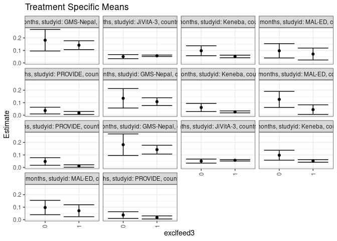

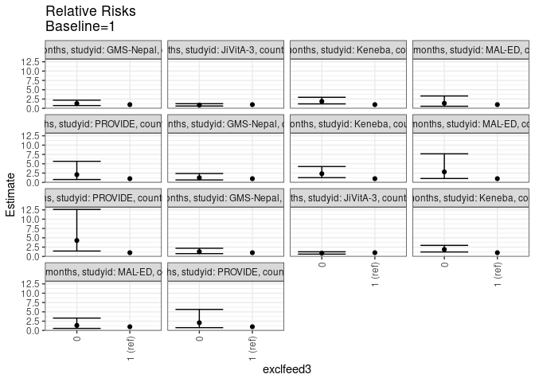

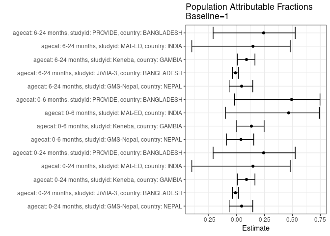

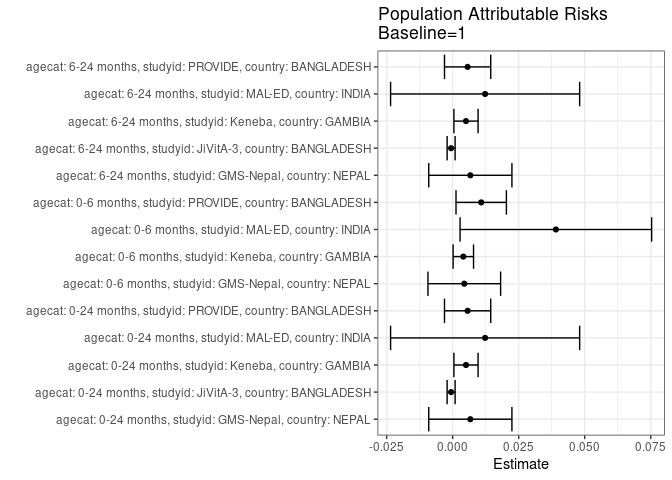

## Results Table

### Parameter: TSM

| agecat | studyid | country | intervention_level | baseline_level | estimate | ci_lower | ci_upper |
| --- | --- | --- | --- | --- | --- | --- | --- |
| 0-24 months | GMS-Nepal | NEPAL | 1 | NA | 0.1421053 | 0.1069610 | 0.1772495 |
| 0-24 months | GMS-Nepal | NEPAL | 0 | NA | 0.1818182 | 0.0955756 | 0.2680608 |
| 0-24 months | JiVitA-3 | BANGLADESH | 1 | NA | 0.0574291 | 0.0516369 | 0.0632213 |
| 0-24 months | JiVitA-3 | BANGLADESH | 0 | NA | 0.0506494 | 0.0343983 | 0.0669004 |
| 0-24 months | Keneba | GAMBIA | 1 | NA | 0.0518732 | 0.0414353 | 0.0623111 |
| 0-24 months | Keneba | GAMBIA | 0 | NA | 0.0976744 | 0.0579816 | 0.1373673 |
| 0-24 months | MAL-ED | INDIA | 1 | NA | 0.0714286 | 0.0236212 | 0.1192360 |
| 0-24 months | MAL-ED | INDIA | 0 | NA | 0.0970874 | 0.0397753 | 0.1543994 |
| 0-24 months | PROVIDE | BANGLADESH | 1 | NA | 0.0177384 | 0.0055465 | 0.0299302 |
| 0-24 months | PROVIDE | BANGLADESH | 0 | NA | 0.0368421 | 0.0100362 | 0.0636481 |
| 0-6 months | GMS-Nepal | NEPAL | 1 | NA | 0.1081794 | 0.0768740 | 0.1394848 |
| 0-6 months | GMS-Nepal | NEPAL | 0 | NA | 0.1351351 | 0.0571574 | 0.2131128 |
| 0-6 months | Keneba | GAMBIA | 1 | NA | 0.0264453 | 0.0186441 | 0.0342464 |
| 0-6 months | Keneba | GAMBIA | 0 | NA | 0.0616114 | 0.0291590 | 0.0940638 |
| 0-6 months | MAL-ED | INDIA | 1 | NA | 0.0446429 | 0.0063065 | 0.0829792 |
| 0-6 months | MAL-ED | INDIA | 0 | NA | 0.1262136 | 0.0619304 | 0.1904968 |
| 0-6 months | PROVIDE | BANGLADESH | 1 | NA | 0.0111359 | 0.0014219 | 0.0208498 |
| 0-6 months | PROVIDE | BANGLADESH | 0 | NA | 0.0476190 | 0.0172344 | 0.0780036 |
| 6-24 months | GMS-Nepal | NEPAL | 1 | NA | 0.1421053 | 0.1069610 | 0.1772495 |
| 6-24 months | GMS-Nepal | NEPAL | 0 | NA | 0.1818182 | 0.0955756 | 0.2680608 |
| 6-24 months | JiVitA-3 | BANGLADESH | 1 | NA | 0.0574291 | 0.0516369 | 0.0632213 |
| 6-24 months | JiVitA-3 | BANGLADESH | 0 | NA | 0.0506494 | 0.0343983 | 0.0669004 |
| 6-24 months | Keneba | GAMBIA | 1 | NA | 0.0518732 | 0.0414353 | 0.0623111 |
| 6-24 months | Keneba | GAMBIA | 0 | NA | 0.0976744 | 0.0579816 | 0.1373673 |
| 6-24 months | MAL-ED | INDIA | 1 | NA | 0.0714286 | 0.0236212 | 0.1192360 |
| 6-24 months | MAL-ED | INDIA | 0 | NA | 0.0970874 | 0.0397753 | 0.1543994 |
| 6-24 months | PROVIDE | BANGLADESH | 1 | NA | 0.0177384 | 0.0055465 | 0.0299302 |
| 6-24 months | PROVIDE | BANGLADESH | 0 | NA | 0.0368421 | 0.0100362 | 0.0636481 |

### Parameter: E(Y)

| agecat | studyid | country | intervention_level | baseline_level | estimate | ci_lower | ci_upper |
| --- | --- | --- | --- | --- | --- | --- | --- |
| 0-24 months | GMS-Nepal | NEPAL | NA | NA | 0.1487965 | 0.1161318 | 0.1814612 |
| 0-24 months | JiVitA-3 | BANGLADESH | NA | NA | 0.0568461 | 0.0514610 | 0.0622312 |
| 0-24 months | Keneba | GAMBIA | NA | NA | 0.0569231 | 0.0466368 | 0.0672094 |
| 0-24 months | MAL-ED | INDIA | NA | NA | 0.0837209 | 0.0466125 | 0.1208293 |
| 0-24 months | PROVIDE | BANGLADESH | NA | NA | 0.0234009 | 0.0116889 | 0.0351130 |
| 0-6 months | GMS-Nepal | NEPAL | NA | NA | 0.1125828 | 0.0834435 | 0.1417221 |
| 0-6 months | Keneba | GAMBIA | NA | NA | 0.0304845 | 0.0226208 | 0.0383482 |
| 0-6 months | MAL-ED | INDIA | NA | NA | 0.0837209 | 0.0466125 | 0.1208293 |
| 0-6 months | PROVIDE | BANGLADESH | NA | NA | 0.0219436 | 0.0105669 | 0.0333202 |
| 6-24 months | GMS-Nepal | NEPAL | NA | NA | 0.1487965 | 0.1161318 | 0.1814612 |
| 6-24 months | JiVitA-3 | BANGLADESH | NA | NA | 0.0568461 | 0.0514610 | 0.0622312 |
| 6-24 months | Keneba | GAMBIA | NA | NA | 0.0569231 | 0.0466368 | 0.0672094 |
| 6-24 months | MAL-ED | INDIA | NA | NA | 0.0837209 | 0.0466125 | 0.1208293 |
| 6-24 months | PROVIDE | BANGLADESH | NA | NA | 0.0234009 | 0.0116889 | 0.0351130 |

### Parameter: RR

| agecat | studyid | country | intervention_level | baseline_level | estimate | ci_lower | ci_upper |
| --- | --- | --- | --- | --- | --- | --- | --- |
| 0-24 months | GMS-Nepal | NEPAL | 1 | 1 | 1.0000000 | 1.0000000 | 1.000000 |
| 0-24 months | GMS-Nepal | NEPAL | 0 | 1 | 1.2794613 | 0.7493895 | 2.184473 |
| 0-24 months | JiVitA-3 | BANGLADESH | 1 | 1 | 1.0000000 | 1.0000000 | 1.000000 |
| 0-24 months | JiVitA-3 | BANGLADESH | 0 | 1 | 0.8819453 | 0.6260000 | 1.242536 |
| 0-24 months | Keneba | GAMBIA | 1 | 1 | 1.0000000 | 1.0000000 | 1.000000 |
| 0-24 months | Keneba | GAMBIA | 0 | 1 | 1.8829457 | 1.1964622 | 2.963307 |
| 0-24 months | MAL-ED | INDIA | 1 | 1 | 1.0000000 | 1.0000000 | 1.000000 |
| 0-24 months | MAL-ED | INDIA | 0 | 1 | 1.3592233 | 0.5568160 | 3.317950 |
| 0-24 months | PROVIDE | BANGLADESH | 1 | 1 | 1.0000000 | 1.0000000 | 1.000000 |
| 0-24 months | PROVIDE | BANGLADESH | 0 | 1 | 2.0769737 | 0.7633930 | 5.650850 |
| 0-6 months | GMS-Nepal | NEPAL | 1 | 1 | 1.0000000 | 1.0000000 | 1.000000 |
| 0-6 months | GMS-Nepal | NEPAL | 0 | 1 | 1.2491760 | 0.6550468 | 2.382182 |
| 0-6 months | Keneba | GAMBIA | 1 | 1 | 1.0000000 | 1.0000000 | 1.000000 |
| 0-6 months | Keneba | GAMBIA | 0 | 1 | 2.3297696 | 1.2738728 | 4.260886 |
| 0-6 months | MAL-ED | INDIA | 1 | 1 | 1.0000000 | 1.0000000 | 1.000000 |
| 0-6 months | MAL-ED | INDIA | 0 | 1 | 2.8271845 | 1.0417139 | 7.672905 |
| 0-6 months | PROVIDE | BANGLADESH | 1 | 1 | 1.0000000 | 1.0000000 | 1.000000 |
| 0-6 months | PROVIDE | BANGLADESH | 0 | 1 | 4.2761905 | 1.4510528 | 12.601750 |
| 6-24 months | GMS-Nepal | NEPAL | 1 | 1 | 1.0000000 | 1.0000000 | 1.000000 |
| 6-24 months | GMS-Nepal | NEPAL | 0 | 1 | 1.2794613 | 0.7493895 | 2.184473 |
| 6-24 months | JiVitA-3 | BANGLADESH | 1 | 1 | 1.0000000 | 1.0000000 | 1.000000 |
| 6-24 months | JiVitA-3 | BANGLADESH | 0 | 1 | 0.8819453 | 0.6260000 | 1.242536 |
| 6-24 months | Keneba | GAMBIA | 1 | 1 | 1.0000000 | 1.0000000 | 1.000000 |
| 6-24 months | Keneba | GAMBIA | 0 | 1 | 1.8829457 | 1.1964622 | 2.963307 |
| 6-24 months | MAL-ED | INDIA | 1 | 1 | 1.0000000 | 1.0000000 | 1.000000 |
| 6-24 months | MAL-ED | INDIA | 0 | 1 | 1.3592233 | 0.5568160 | 3.317950 |
| 6-24 months | PROVIDE | BANGLADESH | 1 | 1 | 1.0000000 | 1.0000000 | 1.000000 |
| 6-24 months | PROVIDE | BANGLADESH | 0 | 1 | 2.0769737 | 0.7633930 | 5.650850 |

### Parameter: PAR

| agecat | studyid | country | intervention_level | baseline_level | estimate | ci_lower | ci_upper |
| --- | --- | --- | --- | --- | --- | --- | --- |
| 0-24 months | GMS-Nepal | NEPAL | 1 | NA | 0.0066912 | -0.0090592 | 0.0224417 |
| 0-24 months | JiVitA-3 | BANGLADESH | 1 | NA | -0.0005830 | -0.0020965 | 0.0009304 |
| 0-24 months | Keneba | GAMBIA | 1 | NA | 0.0050499 | 0.0004801 | 0.0096197 |
| 0-24 months | MAL-ED | INDIA | 1 | NA | 0.0122924 | -0.0235037 | 0.0480884 |
| 0-24 months | PROVIDE | BANGLADESH | 1 | NA | 0.0056626 | -0.0030924 | 0.0144175 |
| 0-6 months | GMS-Nepal | NEPAL | 1 | NA | 0.0044034 | -0.0093536 | 0.0181603 |
| 0-6 months | Keneba | GAMBIA | 1 | NA | 0.0040392 | 0.0001714 | 0.0079071 |
| 0-6 months | MAL-ED | INDIA | 1 | NA | 0.0390781 | 0.0028081 | 0.0753481 |
| 0-6 months | PROVIDE | BANGLADESH | 1 | NA | 0.0108077 | 0.0012697 | 0.0203457 |
| 6-24 months | GMS-Nepal | NEPAL | 1 | NA | 0.0066912 | -0.0090592 | 0.0224417 |
| 6-24 months | JiVitA-3 | BANGLADESH | 1 | NA | -0.0005830 | -0.0020965 | 0.0009304 |
| 6-24 months | Keneba | GAMBIA | 1 | NA | 0.0050499 | 0.0004801 | 0.0096197 |
| 6-24 months | MAL-ED | INDIA | 1 | NA | 0.0122924 | -0.0235037 | 0.0480884 |
| 6-24 months | PROVIDE | BANGLADESH | 1 | NA | 0.0056626 | -0.0030924 | 0.0144175 |

### Parameter: PAF

| agecat | studyid | country | intervention_level | baseline_level | estimate | ci_lower | ci_upper |
| --- | --- | --- | --- | --- | --- | --- | --- |
| 0-24 months | GMS-Nepal | NEPAL | 1 | NA | 0.0449690 | -0.0666291 | 0.1448910 |
| 0-24 months | JiVitA-3 | BANGLADESH | 1 | NA | -0.0102562 | -0.0371130 | 0.0159050 |
| 0-24 months | Keneba | GAMBIA | 1 | NA | 0.0887141 | 0.0063605 | 0.1642422 |
| 0-24 months | MAL-ED | INDIA | 1 | NA | 0.1468254 | -0.4013411 | 0.4805641 |
| 0-24 months | PROVIDE | BANGLADESH | 1 | NA | 0.2419808 | -0.2103743 | 0.5252765 |
| 0-6 months | GMS-Nepal | NEPAL | 1 | NA | 0.0391122 | -0.0908314 | 0.1535765 |
| 0-6 months | Keneba | GAMBIA | 1 | NA | 0.1325009 | 0.0009876 | 0.2467014 |
| 0-6 months | MAL-ED | INDIA | 1 | NA | 0.4667659 | -0.0999062 | 0.7414883 |
| 0-6 months | PROVIDE | BANGLADESH | 1 | NA | 0.4925231 | -0.0191564 | 0.7473078 |
| 6-24 months | GMS-Nepal | NEPAL | 1 | NA | 0.0449690 | -0.0666291 | 0.1448910 |
| 6-24 months | JiVitA-3 | BANGLADESH | 1 | NA | -0.0102562 | -0.0371130 | 0.0159050 |
| 6-24 months | Keneba | GAMBIA | 1 | NA | 0.0887141 | 0.0063605 | 0.1642422 |
| 6-24 months | MAL-ED | INDIA | 1 | NA | 0.1468254 | -0.4013411 | 0.4805641 |
| 6-24 months | PROVIDE | BANGLADESH | 1 | NA | 0.2419808 | -0.2103743 | 0.5252765 |